# ME414 - Estatística para Experimentalistas

## Inferência para duas populações: Teste de hipótese para duas médias

## Teste de hipótese para duas médias

**População 1:** Coletamos uma amostra aleatória \(X_1, X_2, \ldots,X_n\) de uma população com média \(\mu_1\) e a variância \(\sigma_1^2\) e usamos \(\bar{X}\) para estimar \(\mu_1\).

**População 2:** Coletamos uma amostra aleatória \(Y_1, Y_2, \ldots,Y_m\) de uma população com média \(\mu_2\) e a variância \(\sigma_2^2\) e usamos \(\bar{Y}\) para estimar \(\mu_2\).

A população 1 é independente da população 2.

## Teste de hipótese para duas médias

**Condições:**

1. As populações 1 e 2 são aproximadamente normais ou
2. Os tamanhos amostrais \(n\) e \(m\) são suficientemente grandes.

Se pelo menos uma das condições acima é satisfeita, temos: \[\bar{X} \sim N\left(\mu_1,\frac{\sigma_1^2}{n} \right) \quad \mbox{e} \quad \bar{Y} \sim N\left(\mu_2,\frac{\sigma_2^2}{m} \right)\]

## Teste de hipótese para duas médias (\(\sigma_1^2\neq\sigma_2^2\))

**Caso 1: Variâncias diferentes e conhecidas**

Assumindo que as duas amostras \(X_1, \ldots, X_n\) e \(Y_1, \ldots, Y_m\) são independentes com \(\sigma_1^2 \neq \sigma_2^2\) conhecidas, temos:

\[ \bar{X} - \bar{Y} \sim N\left(\mu_1 - \mu_2, \frac{\sigma_1^{2}}{n} + \frac{\sigma_2^{2}}{m} \right)\]

## Teste de hipótese para duas médias (\(\sigma_1^2\neq\sigma_2^2\))

**Caso 1: Variâncias diferentes e conhecidas**

Temos interesse em: \(H_0\): \(\mu_1-\mu_2=\Delta_0\) vs \(H_a\): \(\mu_1-\mu_2\neq\Delta_0\) (ou \(H_a\): \(\mu_1-\mu_2< \Delta_0\) ou \(H_a\): \(\mu_1-\mu_2 > \Delta_0\)).

E daí, sob \(H_0\), temos que: \[Z= \frac{(\bar{X} - \bar{Y}) - \overbrace{(\mu_1 - \mu_2)}^{\Delta_0}}{ \sqrt{\frac{\sigma_1^{2}}{n} + \frac{\sigma_2^{2}}{m}}} \sim N(0, 1)\]

## Teste de hipótese para duas médias (\(\sigma_1^2\neq\sigma_2^2\))

Se temos interesse em: \(H_{0}: \mu_{1}-\mu_{2}=\Delta_{0} \hspace{0.3cm} vs \hspace{0.3cm} H_{a}: \mu_{1}-\mu_{2} > \Delta_{0}\).

> Uma amostra aleatória de tamanho \(m\) é coletada da população \(X\) e calcula-se a média amostral, \(\bar{x}\). Similarmente, para a população \(Y\), temos \(\bar{y}\) obtida a partir de uma amostra aleatória de tamanho \(n\).

\[ \begin{aligned} \mbox{p-valor} & = P\left(\frac{\bar{X}-\bar{Y}-\Delta_{0}}{\sqrt{\sigma_{1}^{2}/n+\sigma_{2}^{2}/m}} \geq \frac{\bar{x}-\bar{y}-\Delta_{0}}{\sqrt{\sigma_1^2/n+\sigma_2^2/m}}\right) = P\left(Z \geq \frac{\bar{x}-\bar{y}-\Delta_{0}}{\sqrt{\sigma_{1}^{2}/n+\sigma_{2}^{2}/m}}\right) \\ & = 1-\Phi\left(\frac{\bar{x}-\bar{y}-\Delta_{0}}{\sqrt{\sigma_{1}^{2}/n+\sigma_{2}^{2}/m}}\right) \nonumber \end{aligned} \] em que \(\Phi(z)=P(Z\leq z)\) para \(Z\sim N(0,1)\).

## Teste de hipótese para duas médias (\(\sigma_1^2\neq\sigma_2^2\))

Se temos interesse em: \(H_{0}: \mu_{1}-\mu_{2}=\Delta_{0} \hspace{0.3cm} vs \hspace{0.3cm} H_{a}: \mu_{1}-\mu_{2} < \Delta_{0}\).

\[ \begin{aligned} \mbox{p-valor} & = P\left(\frac{\bar{X}-\bar{Y}-\Delta_{0}}{\sqrt{\frac{\sigma_{1}^{2}}{n}+\frac{\sigma_{2}^{2}}{m}}} \leq \frac{\bar{x}-\bar{y}-\Delta_{0}}{\sqrt{\frac{\sigma_{1}^{2}}{n}+\frac{\sigma_{2}^{2}}{m}}}\right) \nonumber \\ & = P\left(Z \leq \frac{\bar{x}-\bar{y}-\Delta_{0}}{\sqrt{\frac{\sigma_{1}^{2}}{n}+\frac{\sigma_{2}^{2}}{m}}}\right) = \Phi\left(\frac{\bar{x}-\bar{y}-\Delta_{0}}{\sqrt{\frac{\sigma_{1}^{2}}{n}+\frac{\sigma_{2}^{2}}{m}}}\right) \nonumber \end{aligned} \] em que \(\Phi(z)=P(Z\leq z)\) para \(Z\sim N(0,1)\).

## Teste de hipótese para duas médias (\(\sigma_1^2\neq\sigma_2^2\))

Se temos interesse em: \(H_{0}: \mu_{1}-\mu_{2}=\Delta_{0} \hspace{0.3cm} vs \hspace{0.3cm} H_{a}: \mu_{1}-\mu_{2} \neq \Delta_{0}\).

\[ \begin{aligned} \mbox{p-valor} & = P\left(\frac{|\bar{X}-\bar{Y}-\Delta_{0}|}{\sqrt{\frac{\sigma_{1}^{2}}{n}+\frac{\sigma_{2}^{2}}{m}}} \geq \frac{|\bar{x}-\bar{y}-\Delta_{0}|}{\sqrt{\frac{\sigma_{1}^{2}}{n}+\frac{\sigma_{2}^{2}}{m}}}\right) \nonumber \\ & = P\left(|Z| \geq \frac{|\bar{x}-\bar{y}-\Delta_{0}|}{\sqrt{\frac{\sigma_{1}^{2}}{n}+\frac{\sigma_{2}^{2}}{m}}}\right) = 2\times \left[ 1 - \Phi\left(\frac{|\bar{x}-\bar{y}-\Delta_{0}|}{\sqrt{\frac{\sigma_{1}^{2}}{n}+\frac{\sigma_{2}^{2}}{m}}}\right) \right ]\nonumber \end{aligned} \] em que \(\Phi(z)=P(Z\leq z)\) para \(Z\sim N(0,1)\).

## Teste de hipótese para duas médias (\(\sigma_1^2=\sigma_2^2\))

**Caso 2: Variâncias iguais e conhecidas**

\[ \bar{X} - \bar{Y} \sim N\left(\mu_1 - \mu_2, \frac{\sigma^{2}}{n} + \frac{\sigma^{2}}{m} \right)\]

Temos interesse em: \(H_0\): \(\mu_1-\mu_2=\Delta_0\) vs \(H_a\): \(\mu_1-\mu_2\neq\Delta_0\) (ou \(H_a\): \(\mu_1-\mu_2< \Delta_0\) ou \(H_a\): \(\mu_1-\mu_2 > \Delta_0\)).

E daí, sob \(H_0\), temos que: \[Z= \frac{(\bar{X} - \bar{Y}) - \overbrace{(\mu_1 - \mu_2)}^{\Delta_0}}{ \sqrt{\sigma^2 ( \frac{1}{n} + \frac{1}{m}} )} \sim N(0, 1)\]

## Teste de hipótese para duas médias (\(\sigma_1^2=\sigma_2^2\) desconhecidas)

**Caso 3: Variâncias iguais e desconhecidas**

Assim como no caso de uma média com variância desconhecida, usamos uma estimativa de \(\sigma^2\) e a distribuição normal é substituída pela distribuição \(t\).

No caso de duas populações, o estimador da variância \(\sigma^2\) é a combinação das variâncias amostrais de cada população, ou seja, \[S_p^2 = \frac{(n-1)S_1^2 + (m-1)S_2^2}{n+m-2},\] sendo \(S_i^2\) é a variância amostral da população \(i\).

## Teste de hipótese para duas médias (\(\sigma_1^2=\sigma_2^2\) desconhecidas)

Quando \(\sigma^2\) é conhecida:

\[ \frac{\bar{X} - \bar{Y}-(\mu_1-\mu_2)}{\sqrt{\sigma^2 (1/n + 1/m)}} \sim N(0,1)\]

Quando \(\sigma^2\) é desconhecida: \[ \frac{\bar{X} - \bar{Y}-(\mu_1-\mu_2)}{\sqrt{S_p^2 (1/n + 1/m)}} \sim t_{n+m-2}\]

## Teste de hipótese para duas médias (\(\sigma_1^2=\sigma_2^2\) desconhecidas)

Temos interesse em: \(H_0\): \(\mu_1-\mu_2=\Delta_0\) vs \(H_a\): \(\mu_1-\mu_2\neq\Delta_0\) (ou \(H_a\): \(\mu_1-\mu_2< \Delta_0\) ou \(H_a\): \(\mu_1-\mu_2 > \Delta_0\)).

E daí, sob \(H_0\), temos que: \[T= \frac{(\bar{X} - \bar{Y}) - \overbrace{(\mu_1 - \mu_2)}^{\Delta_0}}{ \sqrt{S_p^2 ( \frac{1}{n} + \frac{1}{m}} )} \sim t_{n+m-2}\]

**Observação:** Se \(n\) e \(m\) são pequenos, as duas amostras devem vir de populações aproximadamente normais. Se \(n\) e \(m\) são grandes, então a distribuição \(t\) com \(n+m-2\) graus de liberdade aproxima-se de uma normal.

## Resumo: Teste de hipótese para duas médias

Para \(H_0\): \(\mu_1-\mu_2=\Delta_0\) vs \(H_1\): \(\mu_1-\mu_2\neq\Delta_0\)

| Variâncias | Estatística do teste | Valor crítico para \(\alpha\) | Valor de p |
| --- | --- | --- | --- |
| Diferentes e conhecidas (\(\sigma_1^2 \neq \sigma_2^2\)) | \[Z= \frac{(\bar{X} - \bar{Y}) - \Delta_0}{ \sqrt{\frac{\sigma_1^{2}}{n} + \frac{\sigma_2^{2}}{m}}} \sim N(0, 1)\] | rejeitar se \(\|z_{obs}\|\geq z_{\alpha/2}\) | \(2 P(Z\geq \|z_{obs}\|)\) |
| Iguais e conhecidas (\(\sigma_1^2 = \sigma_2^2 =\sigma^2\)) | \[Z= \frac{(\bar{X} - \bar{Y}) - \Delta_0}{ \sqrt{\sigma^2 ( \frac{1}{n} + \frac{1}{m}} )} \sim N(0, 1)\] | rejeitar se \(\|z_{obs}\|\geq z_{\alpha/2}\) | \(2 P(Z\geq \|z_{obs}\|)\) |
| Iguais e desconhecidas (\(\sigma_1^2 = \sigma_2^2 =\sigma^2\)) | \[T\sim\frac{(\bar{X} - \bar{Y}) -\Delta_0}{ \sqrt{S_p^2 ( 1/m + 1/n )}}\sim t_{n+m-2}\] | rejeitar se \(\|t_{obs}\|\geq t_{n+m-2,\alpha/2}\) | \(2 P(T\geq \|t_{obs}\|)\) |

## Resumo: Teste de hipótese para duas médias

Para \(H_0\): \(\mu_1-\mu_2=\Delta_0\) vs \(H_1\): \(\mu_1-\mu_2\leq\Delta_0\)

| Variâncias | Estatística do teste | Valor crítico para \(\alpha\) | Valor de p |
| --- | --- | --- | --- |
| Diferentes e conhecidas (\(\sigma_1^2 \neq \sigma_2^2\)) | \[Z= \frac{(\bar{X} - \bar{Y}) - \Delta_0}{ \sqrt{\frac{\sigma_1^{2}}{n} + \frac{\sigma_2^{2}}{m}}} \sim N(0, 1)\] | rejeitar se \(z_{obs}\leq -z_{\alpha}\) | \(P(Z\leq z_{obs})\) |
| Iguais e conhecidas (\(\sigma_1^2 = \sigma_2^2 =\sigma^2\)) | \[Z= \frac{(\bar{X} - \bar{Y}) - \Delta_0}{ \sqrt{\sigma^2 ( \frac{1}{n} + \frac{1}{m}} )} \sim N(0, 1)\] | rejeitar se \(z_{obs}\leq -z_{\alpha}\) | \(P(Z\leq z_{obs})\) |
| Iguais e desconhecidas (\(\sigma_1^2 = \sigma_2^2 =\sigma^2\)) | \[T\sim\frac{(\bar{X} - \bar{Y}) -\Delta_0}{ \sqrt{S_p^2 ( 1/m + 1/n )}}\sim t_{n+m-2}\] | rejeitar se \(t_{obs}\leq -t_{n+m+2,\alpha}\) | \(P(T\leq t_{obs})\) |

## Resumo: Teste de hipótese para duas médias

Para \(H_0\): \(\mu_1-\mu_2=\Delta_0\) vs \(H_1\): \(\mu_1-\mu_2\geq\Delta_0\)

| Variâncias | Estatística do teste | Valor crítico para \(\alpha\) | Valor de p |
| --- | --- | --- | --- |
| Diferentes e conhecidas (\(\sigma_1^2 \neq \sigma_2^2\)) | \[Z= \frac{(\bar{X} - \bar{Y}) - \Delta_0}{ \sqrt{\frac{\sigma_1^{2}}{n} + \frac{\sigma_2^{2}}{m}}} \sim N(0, 1)\] | rejeitar se \(z_{obs}\geq z_{\alpha}\) | \(P(Z\geq z_{obs})\) |
| Iguais e conhecidas (\(\sigma_1^2 = \sigma_2^2 =\sigma^2\)) | \[Z= \frac{(\bar{X} - \bar{Y}) - \Delta_0}{ \sqrt{\sigma^2 ( \frac{1}{n} + \frac{1}{m}} )} \sim N(0, 1)\] | rejeitar se \(z_{obs}\geq z_{\alpha}\) | \(P(Z\geq z_{obs})\) |
| Iguais e desconhecidas (\(\sigma_1^2 = \sigma_2^2 =\sigma^2\)) | \[T\sim\frac{(\bar{X} - \bar{Y}) -\Delta_0}{ \sqrt{S_p^2 ( 1/m + 1/n )}}\sim t_{n+m-2}\] | rejeitar se \(t_{obs}\geq t_{n+m+2,\alpha}\) | \(P(T\geq t_{obs})\) |

## Relembrando: Como encontrar \(z_{\alpha/2}\)

\[P(|Z|\leq z_{\alpha/2})=P(-z_{\alpha/2}\leq Z \leq z_{\alpha/2})=1-\alpha\]

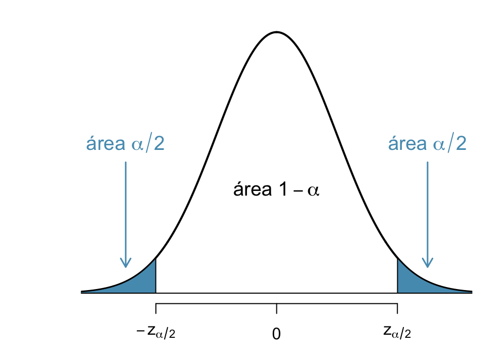

Procure na tabela o valor de \(z\) tal que a probabilidade acumulada até o valor de \(z\), isto é \(P(Z\leq z)=\Phi(z)\), seja \(1-\alpha/2\).

## Relembrando: Como encontrar \(t_{\nu,\alpha/2}\)

\[P(-t_{\nu,\alpha/2} < T < t_{\nu,\alpha/2}) = 1-\alpha\]

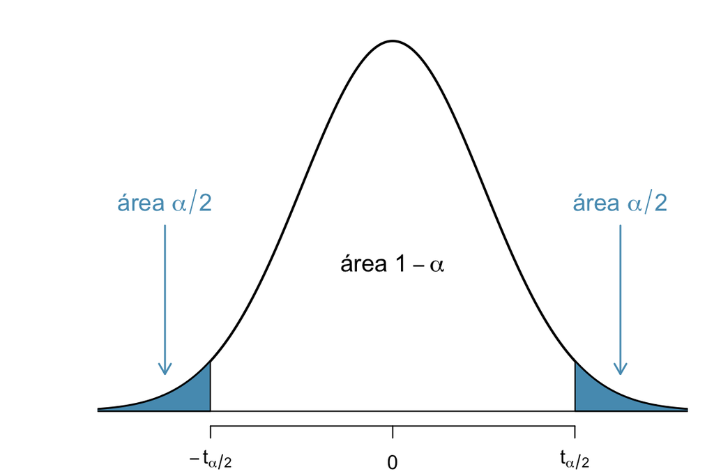

Nesse caso, \(\nu=n+m-2\) e os valores da distribuição \(t\) encontram-se tabelados.

## Exemplo: tempo de incubação de dois vírus

O tempo de incubação do vírus 1 segue uma distribuição normal com média \(\mu_1\) e desvio padrão \(\sigma_{1}=\sqrt{2}\).

Por outro lado, o tempo de incubação do vírus 2 segue uma distribuição normal com média \(\mu_2\) e desvio padrão \(\sigma_{2}=1\).

Os tempos de incubação de ambos os vírus são considerados independentes.

Afirma-se que em média, o tempo de incubação do vírus 1 é 3 meses depois do tempo médio de incubação do vírus 2.

## Exemplo: tempo de incubação de dois vírus

Realizaram um estudo de controle e os tempos de incubação registrados foram (tempo em meses):

- X: tempo de incubação do vírus 1 (20 observações)

```
##  [1] 4.56 3.72 3.45 2.86 4.03 4.08 6.56 4.31 0.42 5.56 5.92 2.65 4.54 4.04
## [15] 4.23 6.24 6.16 5.46 3.22 2.28
```

- Y: tempo de incubação do vírus 2 (22 observações)

```
##  [1] 2.44 1.49 2.68 2.60 1.51 1.60 1.47 3.70 2.22 1.78 2.36 1.56 2.98 3.33
## [15] 2.22 0.58 2.26 2.26 1.92 0.50 1.17 1.70
```

## Exemplo: tempo de incubação de dois vírus

Recentemente, pacientes contaminados com os vírus foram avaliados e suspeita-se que talvez o tempo de incubação do vírus 1 não seja 3 meses depois do tempo médio de incubação do vírus 2.

Definindo as hipóteses as serem testadas:

\(H_{0}: \mu_{1}-\mu_{2}=3 \hspace{0.3cm} vs \hspace{0.3cm} H_{1}: \mu_{1}-\mu_{2}\neq3\)

Os dados coletados serão usados para avaliar se temos ou não evidências contra \(H_0\).

Vamos calcular a média amostral das duas populações: \(\bar x=4.21\) e \(\bar y = 2.02\).

Pelo enunciado, as duas populações são normais e as variâncias são conhecidas: \(\sigma_1^2 = 2\) e \(\sigma_2^2= 1\). Veja que as populações são normais, variâncias diferentes mas conhecidas. Além disso, \(n=20\) e \(m=22\).

## Exemplo: tempo de incubação de dois vírus

Se \(\alpha=0.01\), como p-valor=0.034 \(> \alpha=0.01\), não temos evidência para rejeitar \(H_{0}: \mu_{1}=3+\mu_{2}\) com nível de significância 0.01.

Valor crítico para \(\alpha=0.01\): 2.58, ou seja, se \(|z_{obs}|\geq 2.58\) temos evidências para rejeitar \(H_0\) com nível de significância \(\alpha=0.01\).

## Exemplo: Tecidos

Dois tipos diferentes de tecido devem ser comparados. Uma máquina de testes *Martindale* pode comparar duas amostras ao mesmo tempo. O peso (em miligramas) para sete experimentos foram:

| Tecido | 1 | 2 | 3 | 4 | 5 | 6 | 7 |
| --- | --- | --- | --- | --- | --- | --- | --- |
| A | 36 | 26 | 31 | 38 | 28 | 20 | 37 |
| B | 39 | 27 | 35 | 42 | 31 | 39 | 22 |

Construa um teste de hipótese com nível de significância 5% para testar a hipótese nula de igualdade entre os pesos médios dos tecidos. Admita que a variância é a mesma, e igual a 49.

Quais outras suposições são necessárias para que o teste seja válido?

*Adaptado de: Profa. Nancy Garcia*, Notas de aula.

## Exemplo: Tecidos

Os tecidos do tipo A tem uma média amostral igual a \(\bar{x}_A=30.86\). Já os tecidos do tipo B têm média amostral de \(\bar{x}_B=33.57\).

A variância populacional é igual a 49, enquanto as variâncias amostrais são 44.14 e 52.62, respectivamente.

**Suposições:** Como os tamanhos amostrais \(n=m=7\) são pequenos, devemos assumir os pesos dos tecidos dos dois tipos são normalmente distribuídos ou seja, \(X_A \sim N(\mu_A, \sigma^2)\) e \(X_B \sim N(\mu_B, \sigma^2)\). Além disso são independentes e com variâncias iguais.

## Exemplo: Tecidos

Assumimos que as variâncias são iguais e **conhecidas** (\(\sigma_1^2=\sigma_2^2=49\)). Além disso, \(n=7\) e \(m=7\).

Definindo as hipóteses as serem testadas:

\(H_{0}: \mu_{A}-\mu_{B}=0 \hspace{0.3cm} vs \hspace{0.3cm} H_{1}: \mu_{A}-\mu_{B}\neq 0\).

Como a variância é conhecida, a estatística do teste é dada por \[Z = \frac{\bar{X}_A-\bar{X}_B-\Delta_0}{\sigma \sqrt{\frac{1}{n_A} + \frac{1}{n_B}}}\]

Se a hipótese nula é verdadeira, temos que \(\Delta_0=\mu_A-\mu_B=0\) e \(Z \sim N \left(0, 1 \right)\). Note que a hipótese alternativa é do tipo \(\neq\), então o teste é bilateral.

## Exemplo: Tecidos

\[ \begin{aligned} \mbox{p-valor} & = P\left(\frac{|\bar{X}_A-\bar{X}_B-\Delta_{0}|}{\sigma\sqrt{\frac{1}{n_A}+\frac{1}{n_B}}}\geq \frac{|30.86-33.57-0|}{7\sqrt{\frac{1}{7}+\frac{1}{7}}}\right) \\ & = P\left(|Z|\geq 0.72\right) = 2\times P\left(Z \geq 0.72\right) \\ & = 2\times \left[1-\Phi\left(0.72\right)\right] = 2\times \left[1-0.7642\right] = 0.4716 \end{aligned} \]

Se \(\alpha=0.05\), como p-valor=0.4716 \(> \alpha=0.05\), não temos evidência para rejeitar \(H_{0}: \mu_{A}=\mu_{B}\) com nível de significância 0.05.

Valor crítico para \(\alpha=0.05\): 1.96, ou seja, se \(|z_{obs}|\geq 1.96\) temos evidências para rejeitar \(H_0\) com nível de significância \(\alpha=0.05\).

## Exemplo: Tecidos

Vamos assumir agora que a variância populacional não fosse conhecida.

Assumindo ainda que as variâncias são iguais mas **desconhecidas**, vamos então estimar a variância amostral combinada.

Sabendo que \(s_1^2=44.14\), \(s_2^2=52.62\) e \(n=m=7\) temos: \[\begin{aligned} s_p^2 &= \frac{(n-1)s_1^2 + (m-1)s_2^2}{n+m-2}\\ &= \frac{(7-1) 44.14 + (7-1)52.62}{7 + 7 - 2} \\ &= 48.38 \end{aligned}\]

## Exemplo: Tecidos

Nesse caso, a estatística do teste, sob \(H_0\), é dada por:

\[T=\frac{\bar{X}_A-\bar{X}_B}{\sqrt{S_p^2\left(\frac{1}{n_A}+\frac{1}{n_B}\right)}}\sim t_{n+m-2}\]

\[ \begin{aligned} t_{obs} & =\frac{\bar{x}_A-\bar{x}_B}{\sqrt{s_p^2(1/n_A+1/n_B)}}\\ & =\frac{30.86-33.57}{\sqrt{48.38(1/7+1/7)}}= -0.73 \end{aligned} \]

## Exemplo: Tecidos

Considerando nível de significância 0.05, rejeitamos \(H_0\) se \(|t_{obs}|\geq t_{n+m-2,0.025}\).

Valor crítico para \(\alpha=0.05\): 2.18, ou seja, se \(|t_{obs}|\geq 2.18\) temos evidências para rejeitar \(H_0\) com nível de significância \(\alpha=0.05\). No caso, \(|t_{obs}|=0.73 < 2.18\), portanto não encontramos evidências para rejeitar a hipótese de que as médias são iguais.

## Exemplo: tempo de adaptação

Num estudo comparativo do tempo médio de adaptação (em anos), uma amostra aleatória, de 50 homens e 50 mulheres de um grande complexo industrial, produziu os seguintes resultados:

| Estatística | Homens | Mulheres |
| --- | --- | --- |
| Média | 3.2 | 3.7 |
| Desvio Padrão | 0.8 | 0.9 |

Construa um teste de hipótese com nível de significância de 5% para a diferença entre o tempo médio de adaptação para homens e mulheres.

*Fonte:* Adaptado de Morettin & Bussab, Estatística Básica \(5^a\) edição, pág 365.

## Exemplo: tempo de adaptação

Veja que não sabemos a variância populacional, mas temos os desvios-padrão amostrais e estes são bem próximos. Então iremos assumir que as variâncias são iguais porém desconhecidas.

Nesse caso, vamos então estimar a variância amostral combinada.

Sabendo que \(s_1=0.8\), \(s_2=0.9\) e \(n=m=50\) temos: \[\begin{aligned} s_p^2 &= \frac{(n-1)s_1^2 + (m-1)s_2^2}{n+m-2}\\ &= \frac{(50-1) (0.8)^2 + (50-1)(0.9)^2}{50 + 50 - 2} \\ &= 0.73 \end{aligned}\]

## Exemplo: tempo de adaptação

Nesse caso, a estatística do teste, sob \(H_0\), é dada por:

\[T=\frac{\bar{X}_1 -\bar{X}_2}{\sqrt{S_p^2(\frac{1}{n}+\frac{1}{m})}}\sim t_{n_A+m_B-2}\]

\[ \begin{aligned} t_{obs} & =\frac{\bar{x}_1-\bar{x}_2}{\sqrt{s_p^2(\frac{1}{n}+\frac{1}{m})}}\\ & =\frac{3.2-3.7}{\sqrt{0.73(\frac{1}{50}+\frac{1}{50})}}= -2.93 \end{aligned} \]

## Exemplo: tempo de adaptação

Considerando nível de significância 0.05 e \(H_a\): \(\mu_1\neq\mu_2\), rejeitamos \(H_0\) se \(|t_{obs}|\geq t_{n+m-2,0.025}=1.98\).

Valor crítico para \(\alpha=0.05\): 1.98, ou seja, se \(|t_{obs}|\geq 1.98\) temos evidências para rejeitar \(H_0\) com nível de significância \(\alpha=0.05\). No caso, \(|t_{obs}|=2.93 > 1.98\), portanto encontramos evidências para rejeitar a hipótese de que as médias são iguais.

## Inferência para duas populações: Teste de hipótese para duas proporções

## Teste de hipótese para duas proporções

Considere \(X_1, \ldots,X_{n_1}\) e \(Y_1, \ldots,Y_{n_2}\) duas amostras independentes de ensaios de Bernoulli tal que \(X \sim b(p_1)\) e \(Y \sim b(p_2)\), com probabilidade \(p_1\) e \(p_2\) de apresentarem uma certa característica.

Queremos testar: \(H_0\): \(p_1-p_2=0\) vs \(H_a\): \(p_1-p_2\neq0\) (ou \(H_a\): \(p_1-p_2< 0\) ou \(H_a\): \(p_1-p_2 > 0\)).

Em aulas anteriores vimos que: \[\hat p_1 \sim N\left(p_1,\frac{p_1(1-p_1)}{n_1} \right) \quad \mbox{e} \quad \hat p_2 \sim N\left(p_2,\frac{p_2(1-p_2)}{n_2} \right)\]

Como as variâncias de \(\hat p_1\) e \(\hat p_2\) dependem de \(p_1\) e \(p_2\) e, portanto, não são conhecidas, iremos usar uma estimativa dessas variâncias.

## Teste de hipótese para duas proporções

Sob \(H_0\), \(p_1=p_2=p\), portanto:

\[\hat p_1 \sim N\left(p_1,\frac{p(1-p)}{n_1} \right) \quad \mbox{e} \quad \hat p_2 \sim N\left(p_2,\frac{p(1-p)}{n_2} \right)\]

No entanto, \(p\) é desconhecido. Iremos utilizar como estimativa para \(p\): \(\hat p\), definido como o número de sucessos entre todos os elementos amostrados. Ou seja, o estimador é a proporção de sucessos na amostra toda, sem levar em consideração as populações, pois, sob \(H_0\), \(p_1=p_2\) (não há diferença entre as proporções das duas populações).

## Teste de hipótese para duas proporções

Então, para \(H_0\): \(p_1=p_2\) usamos a estatística do teste a seguir: \[Z = \frac{\hat{p}_1 - \hat{p}_2}{\sqrt{\hat{p}(1 - \hat{p}) \left(\frac{1}{n_1} + \frac{1}{n_2}\right)}} \sim N(0, 1)\]

em que \(\hat p\) é a proporção de sucessos entre os \(n_1 + n_2\) elementos amostrados.

**Condições:** Todas as quantidades \(n_1\hat p_1, \; n_1(1- \hat p_1), \; n_2\hat p_2 \; \mbox{ e } \; n_2(1- \hat p_2)\) devem ser pelo menos igual a 10 para que a aproximação pela normal seja válida.

## Teste de hipótese para duas proporções

Resumindo:

Para \(H_0\): \(p_1-p_2=0\)

| \(H_a\) | Valor crítico para \(\alpha\) | Valor de p |
| --- | --- | --- |
| \(p_1-p_2\neq0\) | rejeitar se \(\|z_{obs}\|\geq z_{\alpha/2}\) | \(2 P(Z\geq \|z_{obs}\|)\) |
| \(p_1-p_2<0\) | rejeitar se \(z_{obs}\leq -z_{\alpha}\) | \(P(Z\leq z_{obs})\) |
| \(p_1-p_2>0\) | rejeitar se \(z_{obs}\geq z_{\alpha}\) | \(P(Z\geq z_{obs})\) |

## Exemplo: decisão sobre gastos

O dinheiro que não é gasto hoje pode ser gasto depois.

> Será que ao relembrar o aluno deste fato faz com que tome a decisão sobre uma compra de maneira diferente?

> O cético pode pensar que relembrar não irá influenciar na decisão.

> Podemos utilizar um teste de hipótese:
- \(H_0\): Relembrar o aluno de que ele pode poupar para comprar algo especial depois não irá influenciar na decisão de gasto do aluno.
- \(H_a\): Relembrar o aluno de que ele pode poupar para comprar algo especial depois irá aumentar a chance dele não gastar em algo no presente.

## Exemplo: decisão sobre gastos

Alunos de ME414 do segundo semestres de 2015 foram recrutados para um estudo e cada um recebeu a seguinte informação através do Google Forms:

*Imagine que você estivesse poupando para comprar algo especial. Em uma visita ao shopping você encontra um DVD da sua série/filme favorita que estava na sua "lista de desejos" há tempos. O DVD está em promoção, custando R$ 20,00. O que você faria?*

56 alunos (grupo 1) selecionados ao acaso receberam a seguinte opção de resposta:

- Compraria o DVD.
- Não compraria o DVD.

54 alunos (grupo 2) selecionados ao acaso receberam a seguinte opção de resposta:

- Compraria o DVD.
- Não compraria o DVD. Pouparia os R$ 20,00 para algo especial.

Obs: estudo adaptado do artigo *[Frederick S, Novemsky N, Wang J, Dhar R, Nowlis S. 2009. Opportunity Cost Neglect. Journal of Consumer Research 36: 553-561.](http://faculty.som.yale.edu/ravidhar/documents/OpportunityCostNeglect.pdf)*

## Exemplo: decisão sobre gastos

|  | Compraria | Não compraria |
| --- | --- | --- |
| grupo1 | 31 | 25 |
| grupo2 | 29 | 25 |

Entre os alunos do grupo 1, a proporção que decide não comprar foi 0.45.

Entre os alunos do grupo 2, a proporção que decide não comprar foi 0.46.

> Temos evidências contra a hipótese nula, ou seja, relembrar o aluno não influencia na decisão?

## Exemplo: decisão sobre gastos

Para realizar o teste de hipótese, devemos fazer algumas suposições.

> Considere duas populações: \(X\) e \(Y\) tal que:
- \(X_i\sim b(p_1)\) indica se o i-ésimo aluno do **grupo 1** decide não comprar o DVD e \(p_1\) é a probabilidade de decidir por não comprar.
- \(Y_i\sim b(p_2)\) indica se o i-ésimo aluno do **grupo 2** decide não comprar o DVD e \(p_2\) é a probabilidade de decidir por não comprar.

> Queremos testar:
- \(H_0\): \(p_1=p_2\)
- \(H_a\): \(p_1 < p_2\)

## Exemplo: decisão sobre gastos

Seja \(\hat{p}_1\) a proporção que decide não comprar entre os alunos \(n_1\) **amostrados do grupo 1**.

Seja \(\hat{p}_2\) a proporção que decide não comprar entre os \(n_2\) alunos **amostrados do grupo 2**.

> Relembrando o TCL:

\[\hat p_1 \sim N\left(p_1,\frac{ p_1(1 - p_1)}{n_1} \right) \quad \mbox{e} \quad \hat p_2 \sim N\left(p_2,\frac{ p_2(1 - p_2)}{n_2} \right)\]

**Condições:** Todas as quantidades \(n_1\hat p_1, \; n_1(1- \hat p_1), \; n_2\hat p_2 \; \mbox{ e } \; n_2(1- \hat p_2)\) devem ser pelo menos igual a 10 para que a aproximação pela normal seja válida.

Então, para \(H_0\): \(p_1=p_2\) usamos a estatística do teste a seguir: \[Z = \frac{(\hat p_1 - \hat p_2)}{\sqrt{\hat p(1 - \hat p) \left(\frac{1}{n_1} + \frac{1}{n_2}\right)}} \sim N(0, 1)\]

em que \(\hat p\) é a proporção que decide não comprar entre os \(n_1 + n_2\) alunos amostrados.

## Exemplo: decisão sobre gastos

\(H_0\): \(p_1=p_2\) vs \(H_a\): \(p_1 < p_2\), que é equivalente a testar: \(H_0\): \(p_1-p_2=0\) vs \(H_a\): \(p_1-p_2<0\).

\[ \begin{aligned} \mbox{p-valor} & = P\left(\frac{\hat p_1-\hat p_2}{\sqrt{\hat p(1 - \hat p) \left(\frac{1}{n_1} + \frac{1}{n_2}\right)}}\leq \frac{25/56-25/54}{\sqrt{5/11(1-5/11)(\frac{1}{56}+\frac{1}{54})}}\right) \\ & = P(Z \leq -0.17) = 0.4325 \end{aligned} \]

Se \(\alpha=0.05\), como p-valor=0.4325 \(> \alpha=0.05\), não temos evidência para rejeitar \(H_{0}\) com nível de significância 0.05.

Valor crítico para \(\alpha=0.05\): -1.64, ou seja, se \(z_{obs}\leq -1.64\) temos evidências para rejeitar \(H_0\) com nível de significância \(\alpha=0.05\).

## Leituras

- [Ross](http://www.sciencedirect.com/science/article/pii/B9780123743886000107): capítulo 10.
- [OpenIntro](https://www.openintro.org/stat/textbook.php): seções 3.2 e 4.3.
- Magalhães: capítulo 9.

Slides produzidos pelos professores:

- Samara Kiihl
- Tatiana Benaglia
- Benilton Carvalho